# Unit III

## Differences of two proportions: Visualizing Confidence Intervals

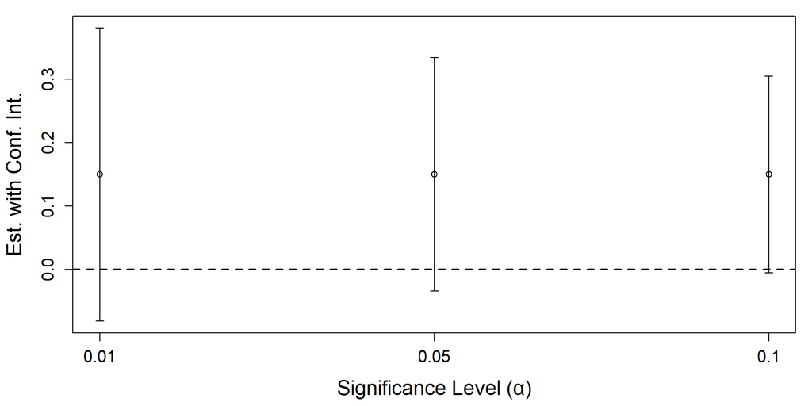

## Differences of Two Proportions: Example 2

- A 5-year clinical trial evaluated whether **fish oil supplements** reduce the risk of **heart attacks**.
- Each participant was randomly assigned to one of two groups:
  - **Fish Oil group**
  - **Placebo group**
- We’ll examine heart attack outcomes across both groups.

## Differences of Two Proportions: Example 2

| Group | Heart Attack | No Event | Total |
| --- | --- | --- | --- |
| Fish Oil | 145 | 12,788 | 12,933 |
| Placebo | 200 | 12,738 | 12,938 |

## Differences of Two Proportions: Example 2

- Construct a **95% confidence interval** for the effect of fish oil on heart attack incidence among patients represented by this study.
- Interpret the interval in context:
  - What does the direction and width of the interval suggest?
  - Is there evidence that fish oil has a meaningful effect on heart attack risk?

## Differences of two proportions: Computing in R

```r
nt <- 12933
nc <- 12938

pt <- 145 / nt
pc <- 200 / nc

point_est <- pt - pc
se <- sqrt((pt * (1 - pt) / nt) + (pc * (1 - pc) / nc))

z <- data.frame(
  sig_level = c(0.01, 0.05, 0.1),
  z_score = c(2.45, 1.95, 1.645)
)

z$min <- point_est - z$z_score * se
z$max <- point_est + z$z_score * se
```

## Differences of two proportions: Visualizing Confidence Intervals

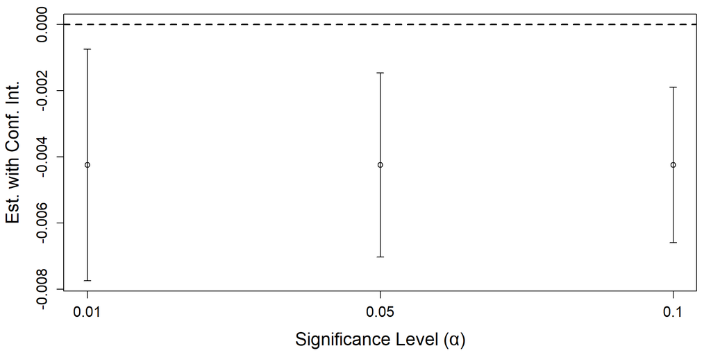

## Differences of two proportions: Interpretation

- The **point estimate** for the effect of fish oil is approximately **–0.0043**,  
  meaning heart attacks occurred **0.43 percentage points less often** in the fish-oil group than in the placebo group.
- We are **90% confident** that fish oil changes the heart-attack rate by between **–0.66 and –0.19 percentage points** for patients similar to those in the study.
- Because this interval **does not include 0**, the reduction in heart-attack risk is **statistically significant** at the 10% (and even 5% an 1%) level.

## Practical vs. Statistical Significance

- While statistically significant, the **effect size is extremely small** — roughly **0.4 fewer heart attacks per 100 individuals**.
- In a large clinical sample, even minor effects can reach significance if variability is low.
- From a **practical** standpoint, such a small reduction may **not justify** the cost, side effects, or adherence burden of treatment.